# miro

Helena L. Crowell

CNAG, Barcelona, Spain

March 09, 2026

#### Package

miro 0.99.0

# 1 preamble

As a proof of concept, we will process 10x Genomics Visium data comprising a single tissue section from a colorectal cancer biopsy (de Oliveira et al. 2025).

## 1.1 libs

```r
library(pals)
library(miro)
library(scran)
library(scater)
library(ggplot2)
library(msigdbr)
library(VisiumIO)
library(patchwork)
library(OSTA.data)
library(HDF5Array)
library(SpatialExperiment)
library(SpatialExperimentIO)
set.seed(260303)
```

## 1.2 data

We’ll start out by retrieving vendor outputs with *OSTA.data*, reading data into a *SpatialExperiment* with *VisiumIO*, and performing minimal processing, namely:

- log-library size normalization
- identifying highly variable features
- principal component analysis (PCA)

```r
# retrieval
id <- "Visium_HumanColon_Oliveira"
pa <- OSTA.data_load(id)
dir.create(td <- tempfile())
unzip(pa, exdir=td)

# loading
spe <- TENxVisium(
    spacerangerOut=file.path(td, "outs"),
    images="lowres", format="h5") |>
    import() |>
    realize()

# wrangling
metadata(spe) <- list()
sym <- rowData(spe)$Symbol
rownames(spe) <- make.unique(sym)
spatialCoordsNames(spe) <- c("x", "y")
img <- as.raster(imgData(spe)$data[[1]])
imgData(spe)$data[[1]] <- SpatialImage(img)
```

Let’s visualize the corresponding hematoxylin and eosin (H&E) staining. On the right-hand side, we crop to the region covered by Visium spots:

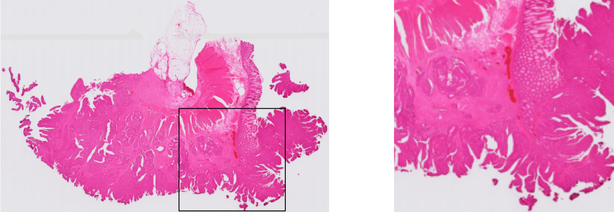

```r
mx <- as.raster(getImg(spe))
sf <- imgData(spe)$scaleFactor
xy <- sf*spatialCoords(spe)
xy <- ceiling(colRanges(xy))
i <- seq(xy[2, 1], xy[2, 2])
j <- seq(xy[1, 1], xy[1, 2])
plot(mx[rev(seq_len(nrow(mx))), ])
do.call(rect, as.list(c(xy)))
plot(mx[rev(i), j])
```

# 2 analysis

## 2.1 reduction

```r
spe <- logNormCounts(spe)
tbl <- modelGeneVar(spe)
hvg <- getTopHVGs(tbl, n=2e3)
spe <- runPCA(spe, subset_row=hvg)
```

## 2.2 deconvolution

```r
# retrieve deconvolution results
# (pre-calculated for runtime reasons)
ws <- readRDS(system.file("extdata", "dec.rds", package="miro"))

# scale weights such that they sum to 1
ws <- sweep(ws, 2, colSums(ws), `/`)

# add proportion estimates as metadata
ws <- data.frame(t(as.matrix(ws)))
colData(spe)[names(ws)] <- ws[colnames(spe), ]

# majority vote assignment
mx <- apply(ws, 1, which.max)
spe$RCTD <- factor(names(ws)[mx])

# compartment-level assignment
lab <- list(
    tum="Tumor",
    epi="Intestinal.Epithelial",
    imm=c("B.cells", "T.cells", "Myeloid"),
    str=c("Endothelial", "Fibroblast", "Smooth.Muscle"))
idx <- match(spe$RCTD, unlist(lab))
lab <- rep.int(names(lab), sapply(lab, length))
table(spe$RCTD, spe$Domain <- factor(lab[idx]))
```

```
##
##                          epi  imm  str  tum
##   B.cells                  0   52    0    0
##   Endothelial              0    0  135    0
##   Fibroblast               0    0  649    0
##   Intestinal.Epithelial  485    0    0    0
##   Myeloid                  0   22    0    0
##   Smooth.Muscle            0    0  372    0
##   T.cells                  0   15    0    0
##   Tumor                    0    0    0 2539
```

# 3 visuals

```r
xy <- spatialCoords(spe); pc <- reducedDim(spe, "PCA")
df <- data.frame(fd <- calcHex(spe), colData(spe), xy, pc)
thm <- \(.="void") list(
    get(paste0("theme_", .))(),
    geom_point(size=1, alpha=2/3),
    coord_equal(), theme(
        panel.border=element_rect(),
        plot.title=element_text(hjust=0.5)))
col_dis <- scale_color_manual(values=unname(trubetskoy()))
col_con <- scale_color_gradientn(colors=rev(hcl.colors(9, "Batlow")))
```

## 3.1 spatial

Let’s start by visualizing the first three PCs over the tissue. In these data, we can observe that they delineate stroma from healthy and malignant epithelium:

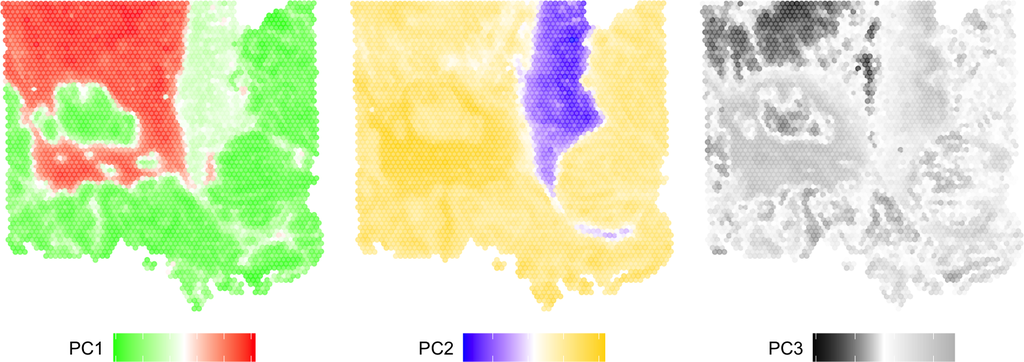

```r
cs <- list(
    PC1=c("green", "white", "red"),
    PC2=c("blue",  "white", "gold"),
    PC3=c("black", "white", "grey"))
ps <- lapply(paste0("PC", seq_len(3)), \(.) {
    pal <- scale_color_gradientn(colors=cs[[.]])
    ggplot(df, aes(x, y, col=.data[[.]])) + pal + thm()
})
wrap_plots(ps, nrow=1) & theme(
      legend.position="bottom",
      legend.text=element_blank())
```

We can now interpret PCs in terms of colors by rescaling and interpreting them as coordinates in the CIELAB color space (see `?colorspace::LAB()`), where

- $a\in[-100,100]$ green-red ($<0$ = green, $>0$ = red)
- $b\in[-100,100]$ blue-yellow ($<0$ = blue, $>0$ = yellow)
- $L\in[0,100]$ lightness or luminance (0 = black, 100 = white).

By default, PCs 1-3 will be used for ABL, but argument `dims` (default `3L`) can be used to control which components to use.

```r
head(fd <- calcHex(spe))
```

```
##                           PC1       PC2         PC3
## AACAATGTGCTCCGAG-1 -43.628352  6.022533 -12.4218270
## AACACCATTCGCATAC-1  69.226179 -7.850156 -10.6582607
## AACACGACAACGGAGT-1 -41.817358  6.377981  -2.0958909
## AACACGCAGATAACAA-1  67.196489  3.663722  -0.4551566
## AACACGTTGATACCGC-1 -21.516673  6.799241   0.3458462
## AACACTCGTGAGCTTC-1   4.348308 23.611565  22.1842221
##                           L         A        B     hex
## AACAATGTGCTCCGAG-1 42.16240 -69.59690 42.76692 #007A0D
## AACACCATTCGCATAC-1 44.11191  68.24118 20.61495 #CD114A
## AACACGACAACGGAGT-1 53.57708 -67.38499 43.33450 #00982D
## AACACGCAGATAACAA-1 55.39081  65.76216 39.00036 #F24345
## AACACGTTGATACCGC-1 56.27627 -42.59017 44.00717 #4C9834
## AACACTCGTGAGCTTC-1 80.41725 -10.99925 70.85316 #D9CB35
```

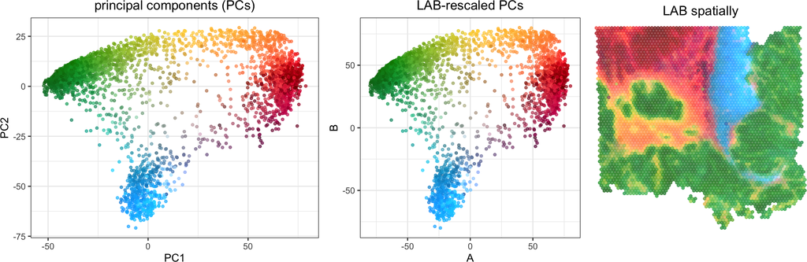

```r
ps <- list(
    ggplot(df, aes(PC1, PC2, col=hex)) +
        thm("bw") + ggtitle("principal components (PCs)"),
    ggplot(fd, aes(A, B, col=hex)) +
        thm("bw") + ggtitle("LAB-rescaled PCs"),
    ggplot(df, aes(x, y, col=hex)) +
        thm() + ggtitle("LAB spatially"))
wrap_plots(ps, nrow=1) & scale_color_identity()
```

For comparison, we also visualize deconvolution results spatially:

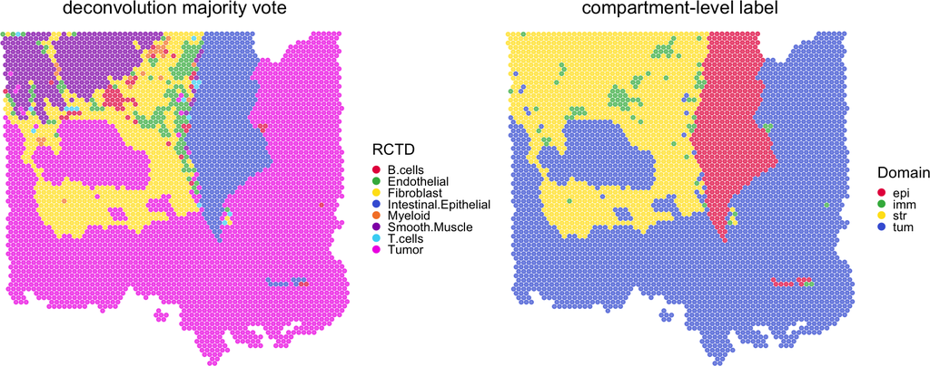

```r
ps <- list(
    ggplot(df, aes(x, y, col=RCTD)) + thm() + ggtitle("deconvolution majority vote"),
    ggplot(df, aes(x, y, col=Domain)) + thm() + ggtitle("compartment-level label"))
wrap_plots(ps, nrow=1) & col_dis &
    theme(legend.key.size=unit(0, "lines")) &
    guides(col=guide_legend(override.aes=list(alpha=1, size=2)))
```

We can also represent higher PCs as LAB, and again visualizing over the tissue to start seeing variability within domains; e.g., we can observe some variability within the tumor (left compared to right) and stroma (smooth muscle vs. fibroblasts).

> TODO: legend, tho not sure what that should look like.

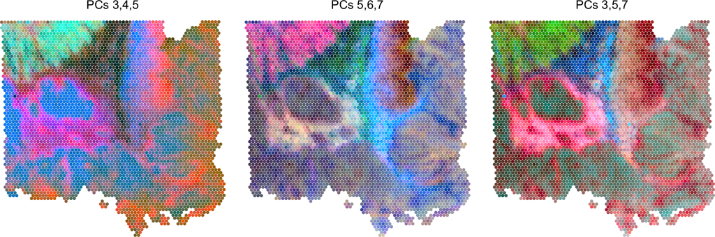

```r
ds <- list(3:5, 5:7, c(3, 5, 7))
ps <- lapply(ds, \(.) {
    lab <- paste("PCs", paste(., collapse=","))
    miroSpatial(spe, dim=.) + ggtitle(lab)
})
wrap_plots(ps, nrow=1) & theme(plot.title=element_text(hjust=0.5))
```

## 3.2 biplot

> TODO: not sure if this is right… features good, but colors silghtly off?

We can also visualize feature loadings in a biplot with the LAB color space as background (note that $L$ remains fixed here). Argument `gs` may be used to control how many features to include; a couple options are now supported:

- passing a character vector to `gs` or an integer, in which case  
  features will be selected according to `how`, where
- `"abs"` gets top-features (per absolute values)
- `"uni"` samples the color space uniformly
- `"min"` gets negatively loaded features
- `"max"` gets positively loaded features

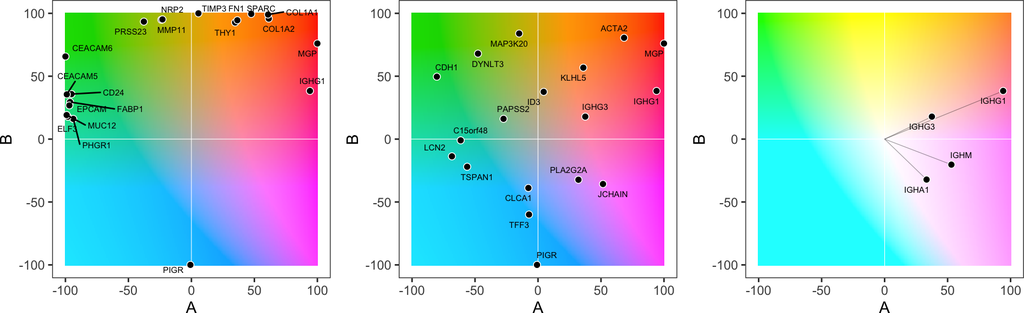

```r
ig <- grepv("^IGH", rownames(spe))
miroBiplot(spe, gs=10, how="abs") +
miroBiplot(spe, gs=20, how="uni") +
miroBiplot(spe, gs=ig, L=100, seg=TRUE)
```

## 3.3 signatures

Because loadings are available for all features underlying PCs (i.e., the HVGs selected above), we can also query gene sets, e.g.:

```r
# retrieve hallmark gene sets from 'MSigDB'
db <- msigdbr(species="Homo sapiens", collection="H")
# get list of gene symbols, one element per set
gs <- split(db$gene_symbol, db$gs_name)
names(gs) <- gsub("HALLMARK_", "", names(gs))
head(names(gs), 8)
```

```
## [1] "ADIPOGENESIS"         "ALLOGRAFT_REJECTION"
## [3] "ANDROGEN_RESPONSE"    "ANGIOGENESIS"
## [5] "APICAL_JUNCTION"      "APICAL_SURFACE"
## [7] "APOPTOSIS"            "BILE_ACID_METABOLISM"
```

We can now project observations into the subspace spanned by these. For this, `miroSpatial()` supports passing a character vector of genes to project:

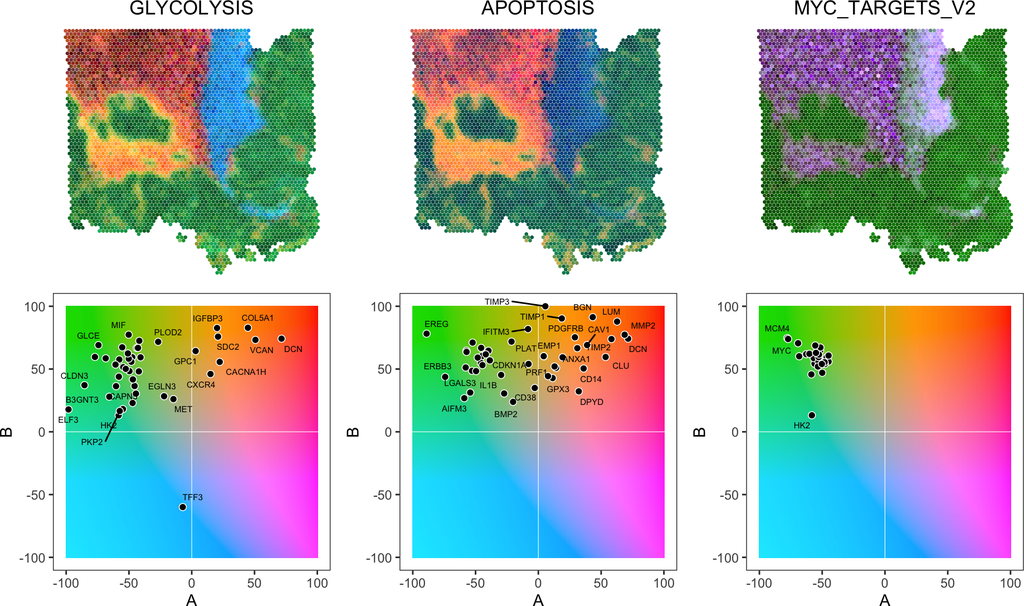

```r
gt <- c("GLYCOLYSIS", "APOPTOSIS", "MYC_TARGETS_V2")
ps <- lapply(gt, \(.) list(
    miroSpatial(spe, gs=gs[[.]], size=1/2) + ggtitle(.),
    miroBiplot(spe, gs=gs[[.]])))
Reduce(c, ps) |>
    wrap_plots(nrow=2, byrow=FALSE) &
    theme(plot.title=element_text(hjust=0.5))
```

## 3.4 regression

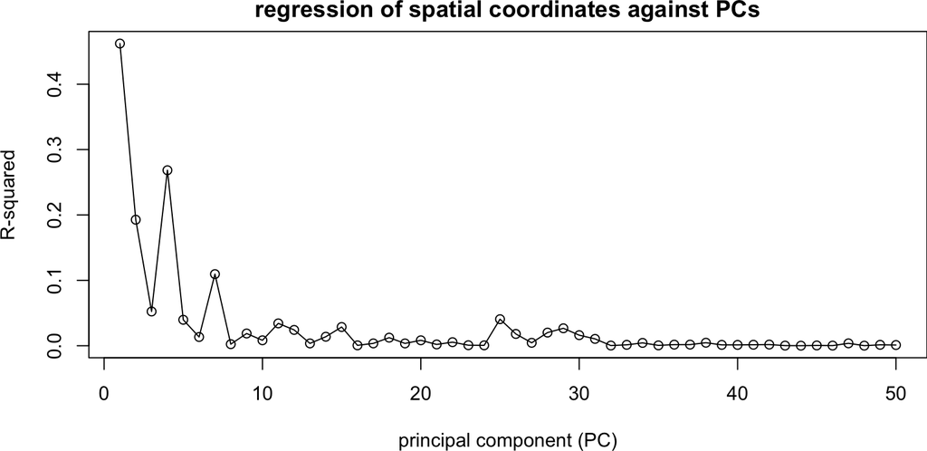

```r
xy <- spatialCoords(spe)
pc <- reducedDim(spe, "PCA")
lm <- summary(lm(pc ~ xy))
r2 <- sapply(lm, \(.) .$r.squared)
plot(r2, type="o",
    xlab="principal component (PC)", ylab="R-squared",
    main="regression of spatial coordinates against PCs")
```

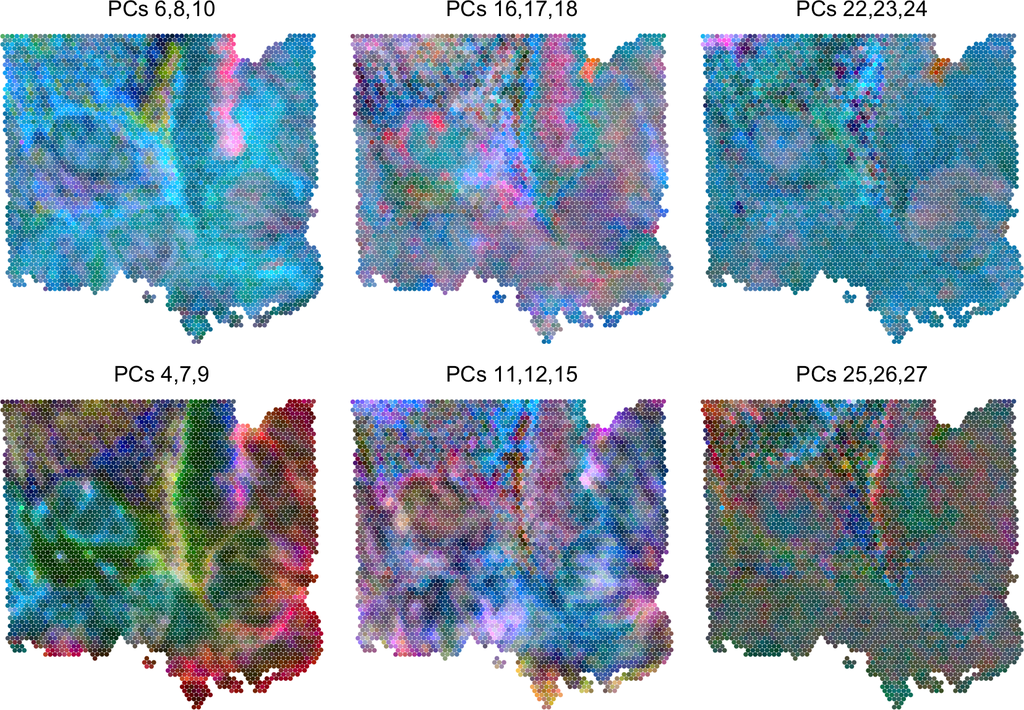

```r
ds <- list(
    # not interesting
    c(6,8,10), 16:18, 22:24,
    # interesting?
    c(4,7,9), c(11,12,15), 25:27)
ps <- lapply(ds, \(.) {
    lab <- paste("PCs", paste(., collapse=","))
    miroSpatial(spe, dim=., size=2/3) + ggtitle(lab)
})
wrap_plots(ps, nrow=2) &
theme(plot.title=element_text(hjust=0.5))
```

```r
# checking out PC8, which has low R2;
# looks like EC and PC markers...
tail(names(sort(abs(attr(pc, "rotation")[, 8]))), 20)
```

```
##  [1] "IGHA1"   "PLVAP"   "CRIP2"   "ECSCR"   "ADIRF"
##  [6] "CPE"     "CALCRL"  "JCHAIN"  "ACKR1"   "IGHG3"
## [11] "MMRN2"   "ID1"     "RAMP3"   "EGFL7"   "AQP1"
## [16] "CLDN5"   "IGKC"    "IGHG1"   "VWF"     "SLCO2A1"
```

# 4 interpretation

## 4.1 loadings

We can now ask something like “Which genes are driving the red region above?”, which would correspond to positive values for PC1; here, these contain clear smooth muscle cell markers (MYL9, MHY11, CNN1, DES, TAGLN, ACTG2, etc.):

```r
pcs <- reducedDim(spe, "PCA")
rot <- attr(pcs, "rotation")
(gs <- tail(names(sort(rot[, 1])), 14))
```

```
##  [1] "MYL9"   "DCN"    "SYNPO2" "C3"     "MYH11"  "CNN1"
##  [7] "GREM1"  "DES"    "TAGLN"  "SFRP2"  "IGKC"   "ACTG2"
## [13] "IGHG1"  "MGP"
```

Let’s check the expression of a few of these:

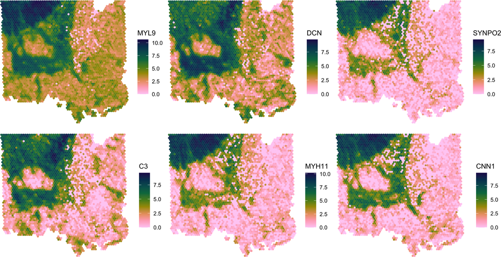

```r
ps <- lapply(head(gs, 6), \(.) {
    df[[.]] <- logcounts(spe)[., ]
    ggplot(df, aes(x, y, col=.data[[.]]))
})
wrap_plots(ps, nrow=2) &
    geom_point(size=1/2) & coord_equal() & thm() &
    scale_color_gradientn(colors=rev(hcl.colors(9, "Batlow")))
```

## 4.2 subsetting

> TODO: option to sample color space in a specific direction.

Let’s dive deeper into the malignant tissue regions. For simplicity, we here subset these by filtering on PCs and recomputing PCs on the remaining cells: (Note that this is a toy example and should not be done in practice.)

```r
idx <- pcs[, 1] < 0 & pcs[, 2] > -20
ncol(sub <- spe[, idx])
```

```
## [1] 2329
```

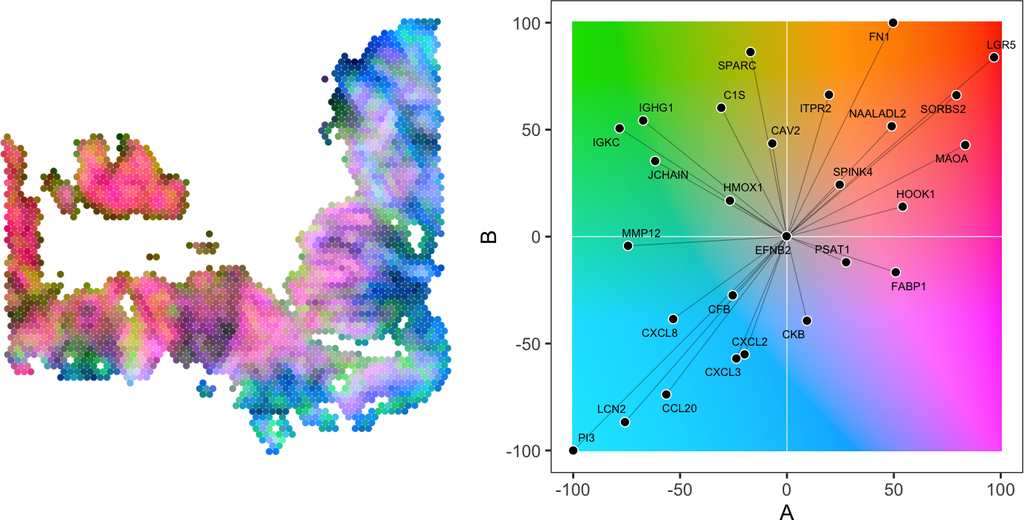

```r
tbl <- modelGeneVar(sub)
hvg <- getTopHVGs(tbl, n=2e3)
sub <- runPCA(sub, subset_row=hvg)
miroSpatial(sub) + miroBiplot(sub, gs=33, seg=TRUE)
```

# 5 projection

We’ll now load up some Xenium data on a disjoint tissue section from the same publication.

```r
# retrieve dataset from OSF
id <- "Xenium_HumanColon_Oliveira"
pa <- OSTA.data_load(id, mol=FALSE)
dir.create(td <- tempfile())
unzip(pa, exdir=td)
# read into 'SpatialExperiment'
xen <- readXeniumSXE(td, addTx=FALSE)
# area-based normalization
sizeFactors(xen) <- (. <- xen$cell_area)/median(.)
(xen <- logNormCounts(xen))
```

```
## class: SpatialExperiment
## dim: 422 340837
## metadata(3): experiment.xenium cell_boundaries
##   nucleus_boundaries
## assays(2): counts logcounts
## rownames(422): ABCC8 ACP5 ... WFDC2 XCL2
## rowData names(3): ID Symbol Type
## colnames(340837): aaaadaba-1 aaaadgga-1 ...
##   oikdmkkf-1 oikeebja-1
## colData names(11): cell_id transcript_counts ...
##   sample_id sizeFactor
## reducedDimNames(0):
## mainExpName: NULL
## altExpNames(3): NegControlProbe UnassignedCodeword
##   NegControlCodeword
## spatialCoords names(2) : x_centroid y_centroid
## imgData names(1): sample_id
```

We can now use the Visium-based rotation to compute corresponding PCs. The LAB representation recapitulates the broad tissue structure from before, where red = stroma, blue = healthy, and green = malignant epithelium.

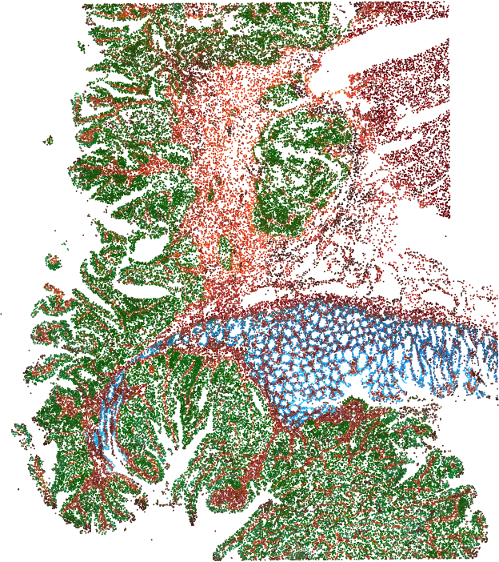

```r
pcs <- reducedDim(spe, "PCA")
rot <- attr(pcs, "rotation")
gt <- intersect(rownames(xen), rownames(rot))
mtx <- t(rot[gt, ]) %*% logcounts(xen)[gt, ]
reducedDim(xen, "PCA") <- as.matrix(t(mtx))

# downsample for plotting
xem <- xen[, sample(ncol(xen), 1e5)]
attr(reducedDim(xem), "rotation") <- rot
miroSpatial(xem, size=0, shape=16)
```

Let’s query some highly loaded features just because we can:

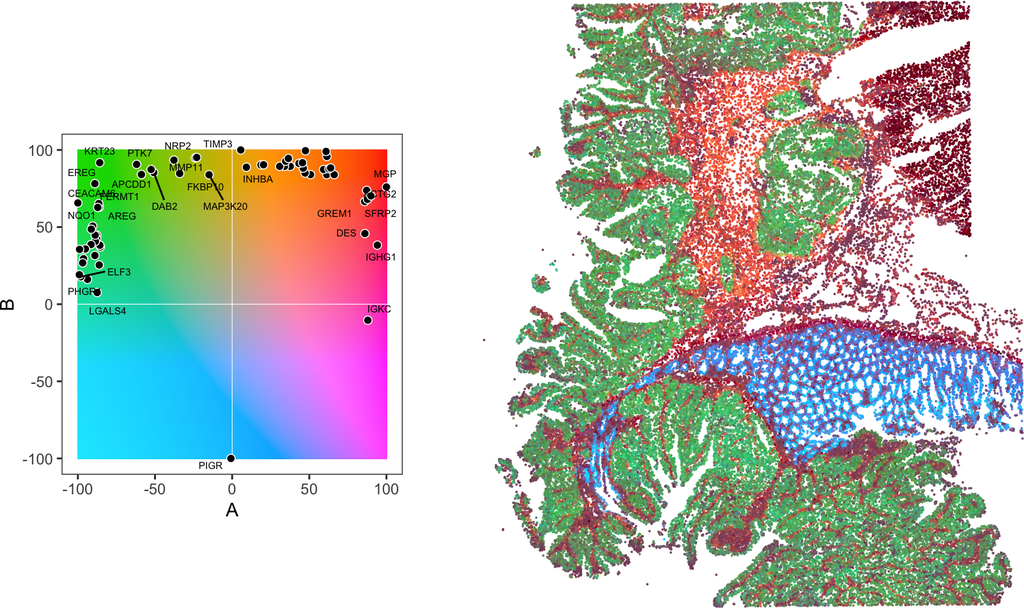

```r
p <- miroBiplot(xem, gs=33, how="abs")
gs <- get_layer_data(p , 5)$label
p + miroSpatial(xem, size=0, gs=gs) + plot_layout(widths=c(1, 2))
```

# 6 appendix

## session

```
## R Under development (unstable) (2025-06-27 r88363)
## Platform: aarch64-apple-darwin20
## Running under: macOS Sequoia 15.6.1
##
## Matrix products: default
## BLAS:   /Library/Frameworks/R.framework/Versions/4.6-arm64/Resources/lib/libRblas.0.dylib
## LAPACK: /Library/Frameworks/R.framework/Versions/4.6-arm64/Resources/lib/libRlapack.dylib;  LAPACK version 3.12.1
##
## locale:
## [1] en_US.UTF-8/en_US.UTF-8/en_US.UTF-8/C/en_US.UTF-8/en_US.UTF-8
##
## time zone: Europe/Madrid
## tzcode source: internal
##
## attached base packages:
```

[output cut: 79 more lines]

de Oliveira, Michelli Faria, Juan Pablo Romero, Meii Chung, Stephen R. Williams, Andrew D. Gottscho, Anushka Gupta, Susan E. Pilipauskas, et al. 2025. “High-Definition Spatial Transcriptomic Profiling of Immune Cell Populations in Colorectal Cancer.” *Nature Genetics* 57: 1512–23. https://doi.org/10.1038/s41588-025-02193-3.